# PM 566 Lab 4

## Chris Hanson

### September 17, 2021

#### The objective of the lab is to examine the association between weekly average dew point temperature and wind speed in four regions of the US and by elevation.

```r
rm(list = ls()) #so I don't delete the first column every time I run the whole script
```

## 1. Read in the data

```r
if (!file.exists("met_all.gz"))
  download.file(
    url = "https://raw.githubusercontent.com/USCbiostats/data-science-data/master/02_met/met_all.gz",
    destfile = "met_all.gz",
    method   = "libcurl",
    timeout  = 60
    )
met <- data.table::fread("met_all.gz")
```

## 2. Prepare the data

```r
# Remove temperatures less than -17C
met <- met[temp >= -17]

# Make sure there are no missing data in the key variables coded as 9999, 999, etc
# temp, rh, wind.sp, vis.dist, dew.point, lat, lon, and elev
met[, range((temp))]
```

```
## [1] -17  56
```

```r
met[, range(rh, na.rm = TRUE)]
```

```
## [1]   0.8334298 100.0000000
```

```r
met[, range(wind.sp, na.rm = TRUE)]
```

```
## [1]  0 36
```

```r
met[, range(vis.dist, na.rm = TRUE)]
```

```
## [1]      0 160000
```

```r
met[, range(dew.point, na.rm = TRUE)]
```

```
## [1] -37.2  36.0
```

```r
met[, range(lat, na.rm = TRUE)]
```

```
## [1] 24.550 48.941
```

```r
met[, range(lon, na.rm = TRUE)]
```

```
## [1] -124.290  -68.313
```

```r
met[, range(elev, na.rm = TRUE)]
```

```
## [1]  -13 9999
```

```r
met[elev == 9999.0, elev :=NA]

# Generate a date variable using the functions as.Date() (hint: You will need the following to create a date paste(year, month, day, sep = "-")).
met[, ymd := as.Date(paste(year, month, day, sep = "-"))]

# Using the data.table::week function, keep the observations of the first week of the month.
met[, table(week(ymd))]
```

```
##
##     31     32     33     34     35
## 297260 521605 527924 523847 446576
```

```r
met <- met[ week(ymd) == 31]

# Compute the mean by station of the variables temp, rh, wind.sp, vis.dist, dew.point, lat, lon, and elev.
met_avg = met[, .(
  temp = mean(temp, na.rm = TRUE),
  rh = mean(rh, na.rm = TRUE),
  wind.sp = mean(wind.sp, na.rm = TRUE),
  vis.dist = mean(vis.dist, na.rm = TRUE),
  dew.point = mean(dew.point, na.rm = TRUE),
  lat = mean(lat, na.rm = TRUE),
  lon = mean(lon, na.rm = TRUE),
  elev = mean(elev, na.rm = TRUE)
), by = "USAFID"]

# Create a region variable for NW, SW, NE, SE based on lon = -98.00 and lat = 39.71 degrees
met_avg[lat >= 39.71 & lon <= -98, region := "Northwest"]
met_avg[lat < 39.71 & lon <= -98, region := "Southwest"]
met_avg[lat >= 39.71 & lon > -98, region := "Northeast"]
met_avg[lat < 39.71 & lon > -98, region := "Southeast"]


# Create a categorical variable for elevation as in the lecture slides
met_avg[, elev_cat := fifelse(elev > 252, "high", "low")]
```

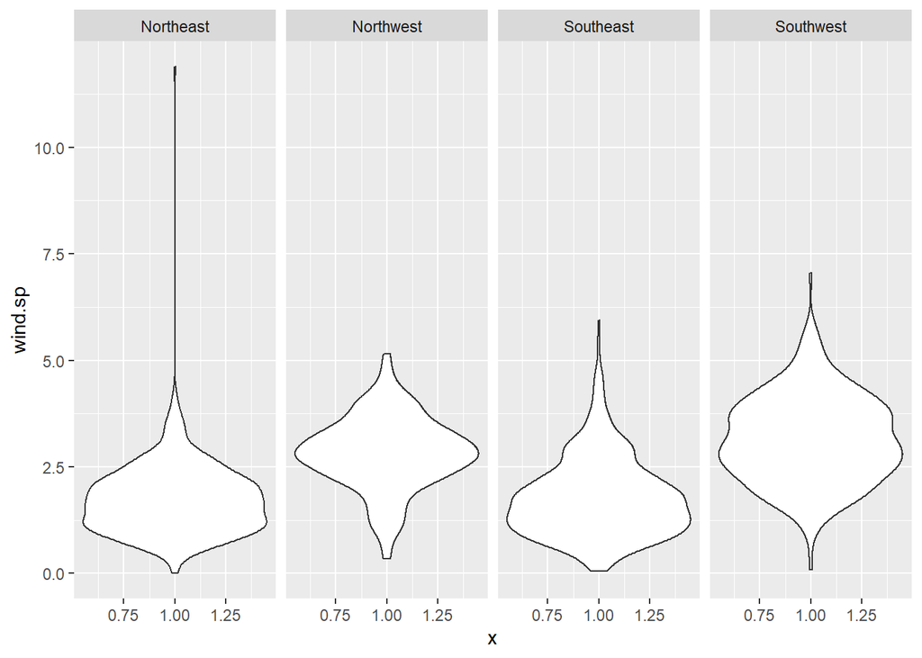

```r
# Use facets. Make sure to deal with NA category. Describe what you observe in the graph.
ggplot(met_avg, mapping = aes(y = wind.sp, x = 1)) +
  geom_violin() +
  facet_grid(~region)
```

## 4. Use geom_jitter with stat_smooth to examine the association between dew point temperature and wind speed by region.

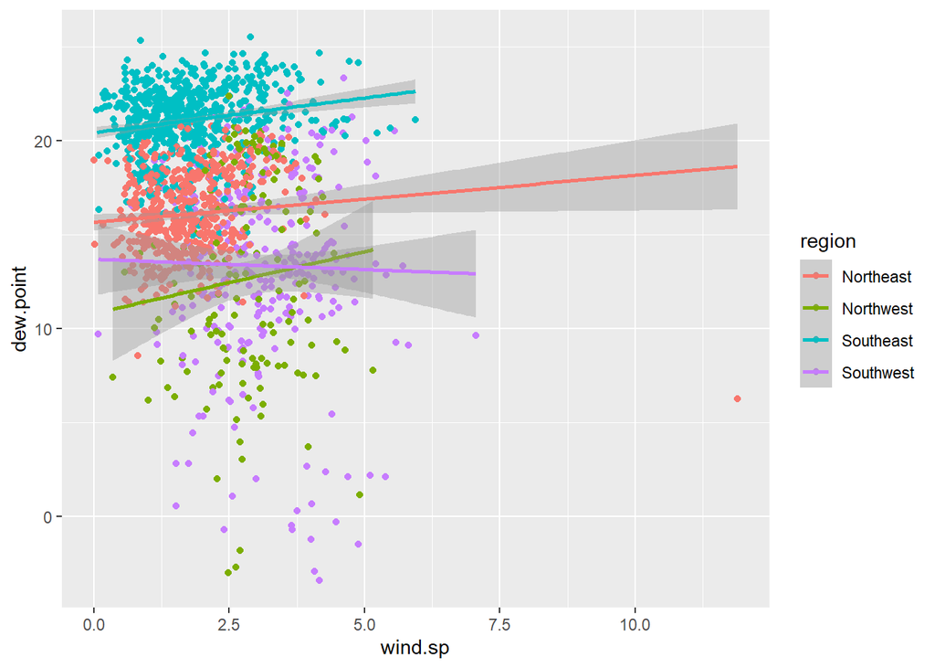

```r
ggplot(data = met_avg, mapping = aes(y = dew.point, x = wind.sp, colour = region)) +
  geom_jitter() +
  stat_smooth(method = lm)
```

```r
# Color points by region XX

# Make sure to deal with NA category XX

# Fit a linear regression line by region

# Describe what you observe in the graph
```

## 5. Use geom_bar to create barplots of the weather stations by elevation category colored by region.

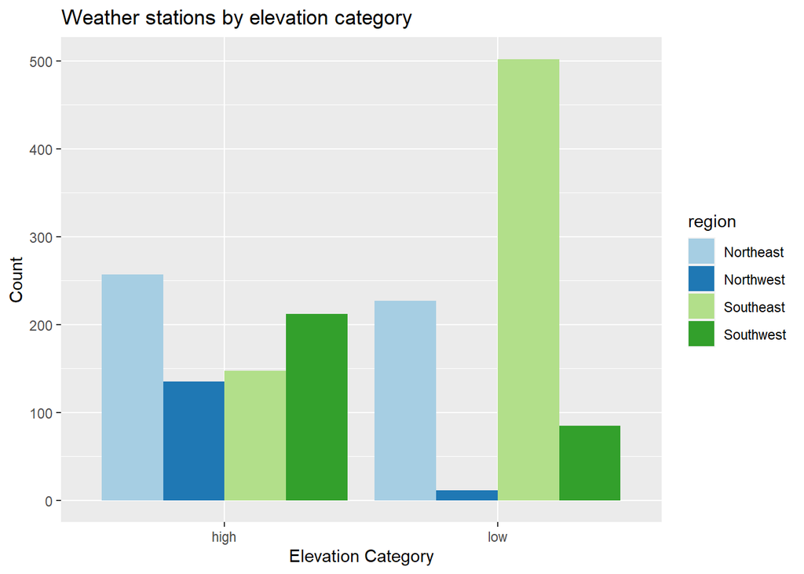

```r
ggplot(data = met_avg[!is.na(elev_cat)], mapping = aes(x = elev_cat, fill = region)) +
  geom_bar(position = "dodge") + scale_fill_brewer(palette = "Paired") +
  ggtitle("Weather stations by elevation category") + xlab("Elevation Category") +
  ylab("Count")
```

```r
# Bars by elevation category using position="dodge"

# Change colors from the default. Color by region using scale_fill_brewer (see note)

# Create nice labels on axes and add a title

# Describe what you observe in the graph

# Make sure to deal with NA
```

Description: The Southeast has a lot of low elevation weather stations, and the Northeast has the most high elevation stations.

## 6. Use stat_summary to examine mean dew point and wind speed by region with standard deviation error bars.

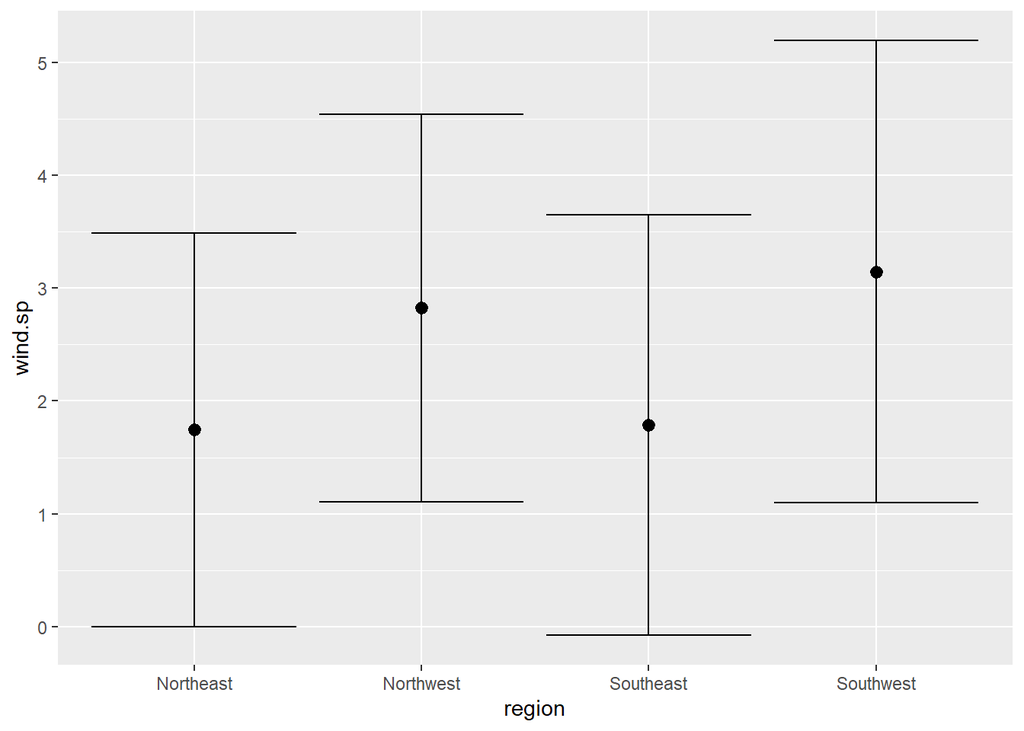

```r
# Describe the graph and what you observe. What is the dew point temperature? What is the wind speed?

ggplot(
  met_avg[!is.na(wind.sp)],
  mapping = aes(x = region, y = wind.sp)) +
  stat_summary(fun.data = "mean_sdl") +
  stat_summary(fun.data = "mean_sdl", geom = "errorbar")
```

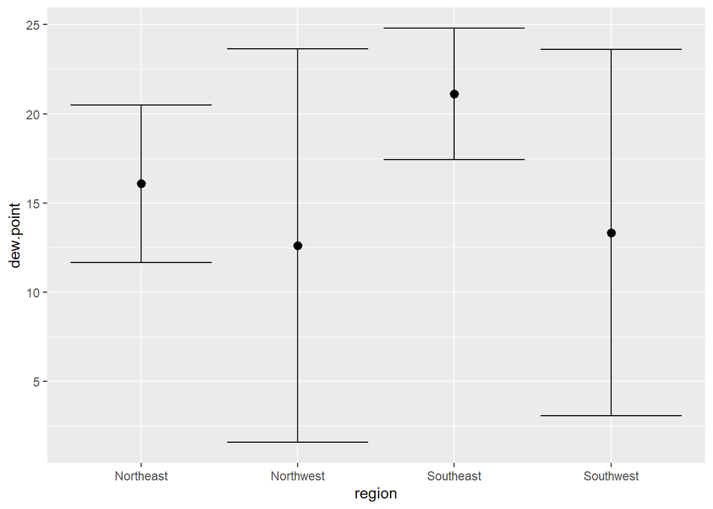

```r
ggplot(
  met_avg[!is.na(dew.point)],
  mapping = aes(x = region, y = dew.point)) +
  stat_summary(fun.data = "mean_sdl") +
  stat_summary(fun.data = "mean_sdl", geom = "errorbar")
```

Description: The NW and SW have higher wind speeds, on average. The spread is pretty consistent across regions. The NW and SW have a greater spread of dew points than the NE and SE, which are also both on average higher.

## 7. Make a map showing the spatial trend in relative h in the US

```r
# Make sure to remove NA. Use leaflet(). Make a color palette with custom colors. Use addMarkers to include the top 10 places in relative h (hint: rank(-rh) <= 10). Add a legend. Describe trend in RH across the US.

library(leaflet)

temp.pal <- colorNumeric(c('darkgreen','goldenrod','brown'), domain=met_avg$rh)

leaflet(met_avg) %>%
  addProviderTiles('CartoDB.Positron') %>%
  addCircles(
    lat = ~lat, lng=~lon,

    label = ~paste0(round(rh,2), ' rh'), color = ~ temp.pal(rh),
    opacity = 1, fillOpacity = 1, radius = 500
    ) %>%

  addLegend('bottomleft', pal=temp.pal, values=met_avg$rh,
          title='Relative Humidity', opacity=1)
```

[interactive chart not shown]

Description: The relative humidity increases as you go east primarily and south secondarily.

## 8. Use a ggplot extension

```r
# Pick an extension (except cowplot) from (link) and make a plot of your choice using the met data (or met_avg). You might want to try examples that come with the extension first (eg ggtech, gganimate, ggforce).

## I'll return to this later if I get time.
```